# R Class Exam 1 José C. Zayas

Jose Zayas

2026-10-22

```r
library(tidyverse)
library(dplyr)
library(aod)
```

## BIOL6997 Prof. Pablo Gutierrez Examen 1

### Mammals sleep dataset (msleep)

### Context / Contexto: You are experts in Mammalogy, and your field technicians have collected data on sleep behavior in different mammal species. Now you must begin exploring how these patterns relate to activity and daily rhythms.

- Hint: “At least” like saying “greater than or equal to,” i.e.

```r
msleep |>
  filter(sleep_total >= 12)
```

```
## # A tibble: 31 × 11
##    name   genus vore  order conservation sleep_total sleep_rem sleep_cycle awake
##    <chr>  <chr> <chr> <chr> <chr>              <dbl>     <dbl>       <dbl> <dbl>
##  1 Cheet… Acin… carni Carn… lc                  12.1      NA        NA      11.9
##  2 Owl m… Aotus omni  Prim… <NA>                17         1.8      NA       7
##  3 Mount… Aplo… herbi Rode… nt                  14.4       2.4      NA       9.6
##  4 Great… Blar… omni  Sori… lc                  14.9       2.3       0.133   9.1
##  5 Three… Brad… herbi Pilo… <NA>                14.4       2.2       0.767   9.6
##  6 Chinc… Chin… herbi Rode… domesticated        12.5       1.5       0.117  11.5
##  7 Long-… Dasy… carni Cing… lc                  17.4       3.1       0.383   6.6
##  8 North… Dide… omni  Dide… lc                  18         4.9       0.333   6
##  9 Big b… Epte… inse… Chir… lc                  19.7       3.9       0.117   4.3
## 10 Weste… Euta… herbi Rode… <NA>                14.9      NA        NA       9.1
## # ℹ 21 more rows
## # ℹ 2 more variables: brainwt <dbl>, bodywt <dbl>
```

#### 2. Use mutate() to create a new column called percent_day_awake that gives the percentage of the day that each species spends awake.

#### Use select() with everything() at the end to verify your calculation. Usa select() con everything() al final para comprobar que tus cálculos son correctos.

- Hint: A day has 24 hours. The column awake indicates the average hours a species is awake per day. Calculate the percentage with (col / 24) * 100.

```r
msleep |>
  mutate(percent_day_awake = (awake/24)*100) |>
  select(percent_day_awake, everything())
```

```
## # A tibble: 83 × 12
##    percent_day_awake name   genus vore  order conservation sleep_total sleep_rem
##                <dbl> <chr>  <chr> <chr> <chr> <chr>              <dbl>     <dbl>
##  1              49.6 Cheet… Acin… carni Carn… lc                  12.1      NA
##  2              29.2 Owl m… Aotus omni  Prim… <NA>                17         1.8
##  3              40   Mount… Aplo… herbi Rode… nt                  14.4       2.4
##  4              37.9 Great… Blar… omni  Sori… lc                  14.9       2.3
##  5              83.3 Cow    Bos   herbi Arti… domesticated         4         0.7
##  6              40   Three… Brad… herbi Pilo… <NA>                14.4       2.2
##  7              63.8 North… Call… carni Carn… vu                   8.7       1.4
##  8              70.8 Vespe… Calo… <NA>  Rode… <NA>                 7        NA
##  9              57.9 Dog    Canis carni Carn… domesticated        10.1       2.9
## 10              87.5 Roe d… Capr… herbi Arti… lc                   3        NA
## # ℹ 73 more rows
## # ℹ 4 more variables: sleep_cycle <dbl>, awake <dbl>, brainwt <dbl>,
## #   bodywt <dbl>
```

### Storm tracks data (storms)

### Context / Contexto: You are part of a climatology research group analyzing storm trajectories in the Atlantic. Your team has assembled a long-term dataset, and your task is to start identifying temporal trends and patterns in storm intensity.

- Hint group_by(col) groups the rows by time, and summarise(num_storms = n()) counts how many rows (storms) there are per year.

```r
storms |>
  group_by(year) |>
  summarise(num_storms = n())
```

```
## # A tibble: 50 × 2
##     year num_storms
##    <dbl>      <int>
##  1  1975        238
##  2  1976        126
##  3  1977         92
##  4  1978        152
##  5  1979        324
##  6  1980        335
##  7  1981        311
##  8  1982        111
##  9  1983         88
## 10  1984        342
## # ℹ 40 more rows
```

#### 4. Use filter() to subset storms to only storms with wind speeds greater than 50 knots, then use arrange() to sort by wind descending.

- Hint Use filter(col > 50) to select strong storms, and arrange(desc(col)) to sort the results from highest to lowest.

```r
storms |>
  filter(wind > 50) |>
  arrange(desc(wind))
```

```
## # A tibble: 7,406 × 13
##    name     year month   day  hour   lat  long status    category  wind pressure
##    <chr>   <dbl> <dbl> <int> <dbl> <dbl> <dbl> <fct>        <dbl> <int>    <int>
##  1 Allen    1980     8     7    18  21.8 -86.4 hurricane        5   165      899
##  2 Gilbert  1988     9    14     0  19.7 -83.8 hurricane        5   160      888
##  3 Wilma    2005    10    19    12  17.3 -82.8 hurricane        5   160      882
##  4 Dorian   2019     9     1    16  26.5 -77   hurricane        5   160      910
##  5 Dorian   2019     9     1    18  26.5 -77.1 hurricane        5   160      910
##  6 Allen    1980     8     5    12  15.9 -70.5 hurricane        5   155      932
##  7 Allen    1980     8     7    12  21   -84.8 hurricane        5   155      910
##  8 Allen    1980     8     8     0  22.2 -87.9 hurricane        5   155      920
##  9 Allen    1980     8     9     6  25   -94.2 hurricane        5   155      909
## 10 Gilbert  1988     9    14     6  19.9 -85.3 hurricane        5   155      889
## # ℹ 7,396 more rows
## # ℹ 2 more variables: tropicalstorm_force_diameter <int>,
## #   hurricane_force_diameter <int>
```

### A Comparison of Site Preferences of Two Species of Lizard (lizards)

### Context / Contexto: You are field ecologists studying habitat use by two Anolis species. Your team has spent weeks observing their behavior at different times of day and in varying microhabitats. Now it’s time to analyze the data to test your hypotheses.

#### 5. Determine which Site and Diameter combination has the highest total grahami.

- Hint: group_by(col1, col2) %>% summarise(new_var = sum(var)) %>% arrange(desc(new_var))

```r
lizards |>
  group_by(Site, Diameter) %>% summarise(HighestGrahami= sum(grahami)) %>% arrange(desc(HighestGrahami))
```

[output not shown]

```
## # A tibble: 4 × 3
## # Groups:   Site [2]
##   Site  Diameter HighestGrahami
##   <fct> <fct>             <dbl>
## 1 Shade D <= 2              220
## 2 Shade D > 2               122
## 3 Sun   D <= 2               65
## 4 Sun   D > 2                24
```

#### 6. Create a boxplot showing the distribution of opalinus counts under different light conditions (Sun vs. Shade) using ggplot2.

- Hint: Use ggplot(), aes(), and geom_boxplot(). Sugerencia: Usa ggplot(), aes() y geom_boxplot()

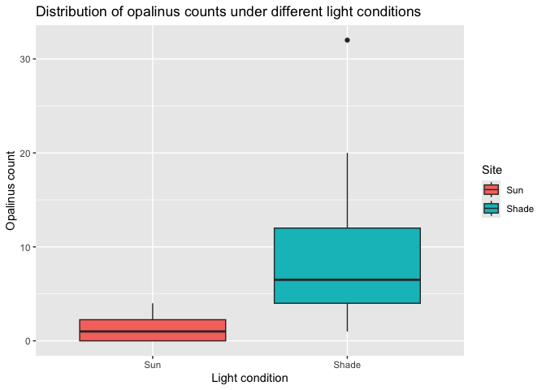

```r
lizards |>
  ggplot(aes(x = Site, y = opalinus, fill = Site)) +
  geom_boxplot() +
  labs(title = "Distribution of opalinus counts under different light conditions",
       x = "Light condition",
       y = "Opalinus count")
```